# Personal Activity Monitoring Data

Bhaskar Sharma

22/09/2020

## Activity Monitoring

It is now possible to collect a large amount of data about personal movement using activity monitoring devices such as a Fitbit, Nike Fuelband, or Jawbone Up. These type of devices are part of the “quantified self” movement – a group of enthusiasts who take measurements about themselves regularly to improve their health, to find patterns in their behavior, or because they are tech geeks. But these data remain under-utilized both because the raw data are hard to obtain and there is a lack of statistical methods and software for processing and interpreting the data..

It’s assumed that ggplot2 library has alread been loaded. The data was read as follows.

```r
activity<-read.csv(unzip("activity.zip"))
#converting to date format
activity$date<-as.Date(activity$date)
head(activity)
```

```
##   steps       date interval
## 1    NA 2012-10-01        0
## 2    NA 2012-10-01        5
## 3    NA 2012-10-01       10
## 4    NA 2012-10-01       15
## 5    NA 2012-10-01       20
## 6    NA 2012-10-01       25
```

```r
agg.interval<-aggregate(activity$steps~ activity$interval, FUN=mean)

#Function which will grab the mean from the required intervals
grabmean<- function(i){
    na_interval<-activity[i,3]
    mean<-agg.interval[which(agg.interval[[1]]==na_interval),2]
    return (mean)

}

#New Data frame
newactivity<-activity
for (i in which(is.na(activity$steps))) {
  populate<-grabmean(i)
  activity[i,1]<-populate

}

head(newactivity)
```

```
##   steps       date interval
## 1    NA 2012-10-01        0
## 2    NA 2012-10-01        5
## 3    NA 2012-10-01       10
## 4    NA 2012-10-01       15
## 5    NA 2012-10-01       20
## 6    NA 2012-10-01       25
```

### Steps Vs. Days Graph

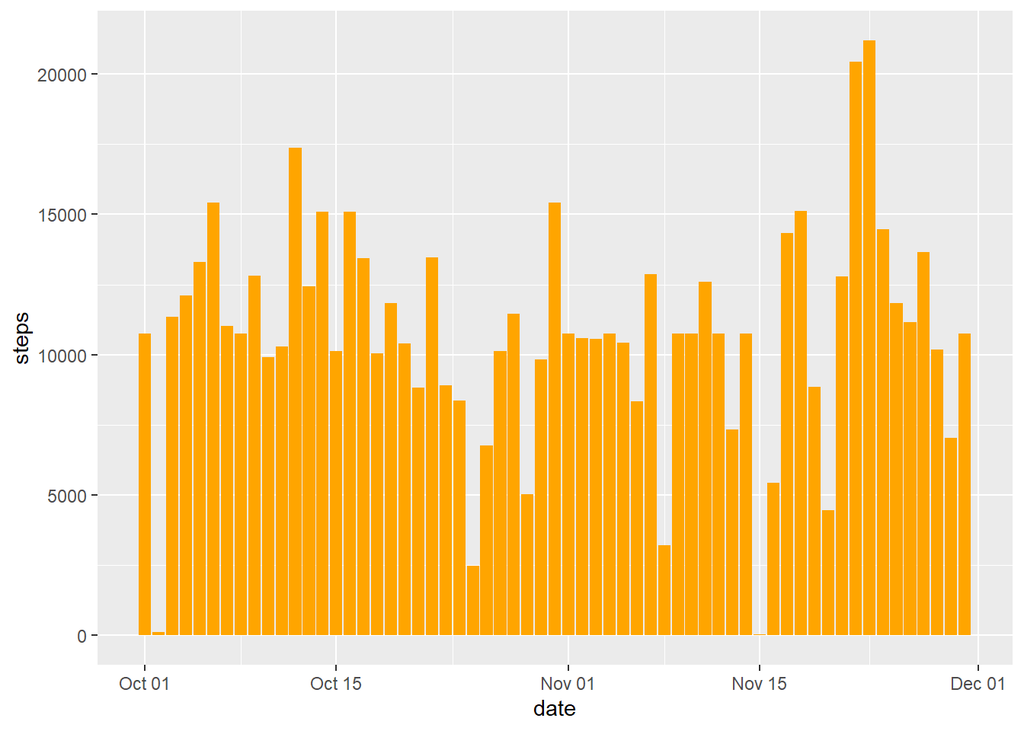

```r
g<-g<-ggplot(data=activity, aes(date, steps))
g+geom_col(fill="orange")
```

### Adding the week column containing the information about weekdays

```r
weekdays<-weekdays(newactivity$date)
newactivity<-cbind(newactivity, weekdays)

weekday<-c("Monday", "Tuesday", "Wednesday", "Thursday", "Friday")
weekend<-c("saturday","saturday")

for (i in seq(1:nrow(newactivity))){
  if (newactivity$weekdays[i] %in% weekday) {newactivity$week[i]="Weekday"}
  else {newactivity$week[i]="Weekend"}
}
head(newactivity)
```

```
##   steps       date interval weekdays    week
## 1    NA 2012-10-01        0   Monday Weekday
## 2    NA 2012-10-01        5   Monday Weekday
## 3    NA 2012-10-01       10   Monday Weekday
## 4    NA 2012-10-01       15   Monday Weekday
## 5    NA 2012-10-01       20   Monday Weekday
## 6    NA 2012-10-01       25   Monday Weekday
```

### Subsetting the data to extract the required information.

```r
day<-subset(newactivity, week=="Weekday")
end<-subset(newactivity, week=="Weekend")
agg.end<-aggregate(end$steps~end$interval, FUN=mean)
agg.day<-aggregate(day$steps~day$interval, FUN=mean)


names(agg.day)<-c("Interval", "Steps")
names(agg.end)<-c("Interval", "Steps")

head(agg.day)
```

```
##   Interval     Steps
## 1        0 2.3333333
## 2        5 0.4615385
## 3       10 0.1794872
## 4       15 0.2051282
## 5       20 0.1025641
## 6       25 1.5128205
```

```r
head(agg.end)
```

```
##   Interval    Steps
## 1        0 0.000000
## 2        5 0.000000
## 3       10 0.000000
## 4       15 0.000000
## 5       20 0.000000
## 6       25 3.714286
```

### Plotting Interval Vs. Steps Graph for Weekend and Weekdays

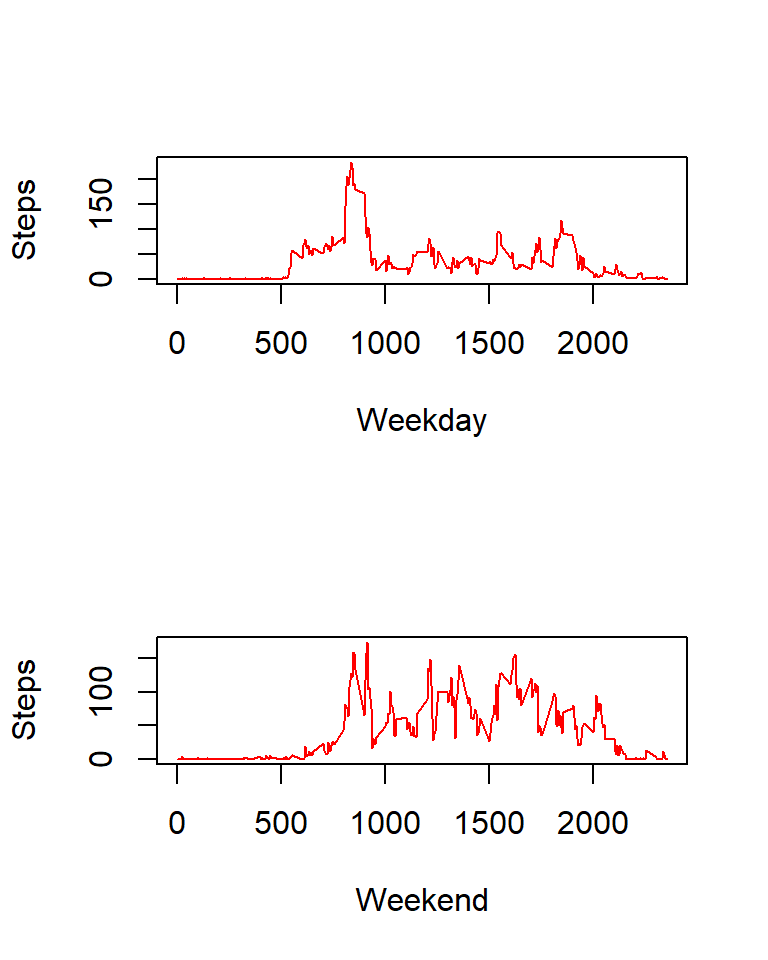

```r
par(mfrow=c(2,1))
with(agg.day, plot(Interval, Steps, type="l", xlab = "Weekday", col="red"))
with(agg.end, plot(Interval, Steps, type="l", xlab="Weekend", col="red"))
```

- As seen, the initial intervals for weekends’ have recorded lesser activities which can be justified as people tend to wake up later than they do on weeek days.
- Also, the concluding intervals witness more activity on weekends as people generally go to bed earlier on weekdays.
- The intervals which are in middle witness less activity on weekdays which can be explained by the fact that people are generally in their offices, classes during the day which restricts their movement.